# Practice 2

### Gradient boosting

With gradient boosting:

```r
xgb_tune = train(model,
                  data = r_tr,
                  method = "xgbTree",
                  preProc=c('scale','center'),
                  objective="reg:squarederror",
                  trControl = ctrl,
                  tuneGrid = expand.grid(nrounds = c(500), max_depth = c(6), eta = c(0.1),
                                         gamma = c(2), colsample_bytree = c(1),
                                         min_child_weight = c(1), subsample = c(0.8))) #already tuned too

xgb_tune
```

```
## eXtreme Gradient Boosting
##
## 5927 samples
##   10 predictor
##
## Pre-processing: scaled (19), centered (19)
## Resampling: Cross-Validated (5 fold)
## Summary of sample sizes: 4741, 4742, 4742, 4743, 4740
## Resampling results:
##
##   RMSE      Rsquared   MAE
##   3.230923  0.9253996  2.121539
##
## Tuning parameter 'nrounds' was held constant at a value of 500
## Tuning
##  held constant at a value of 1
## Tuning parameter 'subsample' was held
##  constant at a value of 0.8
```

Very computationally expensive to tune several parameters, so I put the best tune obtained directly for a faster knitting of the html.

```r
results$xgb = predict(xgb_tune, r_ts)

postResample(pred = results$xgb,  obs = results$demand)
```

```
##      RMSE  Rsquared       MAE
## 3.0688148 0.9340325 2.0044605
```

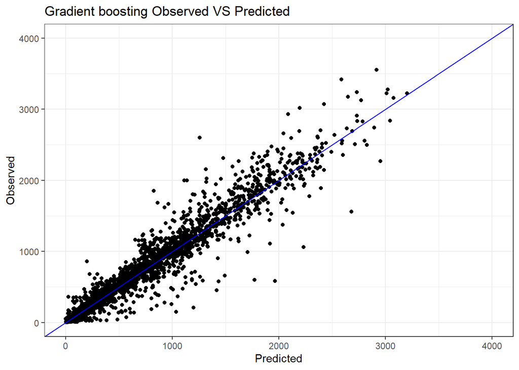

```r
qplot(results$xgb^2, results$demand^2) +
  labs(title="Gradient boosting Observed VS Predicted", x="Predicted", y="Observed") +
  lims(x = c(0, 4000), y = c(0, 4000)) +
  geom_abline(intercept = 0, slope = 1, colour = "blue") +
  theme_bw()
```

Not as many errors as before. Seeing how it started with the multivariate linear regression, it is a huge improvement on prediction.

## Conclusions

From the data about Seoul weather, date and demand, we were able to extract important information about the features (such as the influence of daylight and temperature) and build a model to predict accurately both in classification and regression. We can assert that most statistical learning methods are not as accurate as machine learning algorithms, but they usually offer more explainability.

## References

Drey (https://stats.stackexchange.com/users/10539/drey), Is hour of day a categorical variable?, URL (version: 2019-10-10): https://stats.stackexchange.com/q/245887

Marc in the box (https://stackoverflow.com/users/1199289/marc-in-the-box), Plot logistic regression curve in R, URL https://stackoverflow.com/questions/36685921/plot-logistic-regression-curve-in-r